# CDF reader benchmarks

- Show All Code
- Hide All Code
- View Source

Abstract

Although not a full-featured CDF library (writing is not supported yet) like CDFpp or CDFlib, `CommonDataFormat.jl` offers a fast and user-friendly interface for reading CDF files, implemented entirely in Julia. It supports partial loading and multi-threaded access, enabling efficient reading of selected variables or time intervals—particularly beneficial when working with large CDF datasets.

Reading [Common Data Format (CDF)](https://cdf.gsfc.nasa.gov/) files is a common task in space physics. Here we compare the performance of different implementations of CDF reader (Julia, C++, Python, etc.)

- CommonDataFormat.jl
- CDFpp
- CDFlib

See [benchmarks.ipynb - CDFpp](https://github.com/SciQLop/CDFpp/blob/main/notebooks/benchmarks.ipynb) for a relative comparison of CDFpp and other CDF readers.

## Feature Comparison

| Feature | CommonDataFormat.jl | CDFpp | CDFlib |
| --- | --- | --- | --- |
| **Language** | Julia | C++ (Python wrappers) | Python |
| **Lazy loading** | ✅ Yes | ✅ Yes | ❌ No |
| **Partial Loading** | ✅ Yes | ❌ No | ❌ No |
| **Parallel loading** | ✅ Yes | Thread-safe | ❌ No |
| **CDF writing** | ❌ No | ✅ Yes | ✅ Yes |

## Setup

```julia
dir = "tutorials/cdf"
if isdir(dir)
    cd(dir)
end

Pkg.activate(".")
Pkg.resolve()
Pkg.instantiate()

using CommonDataFormat
using Downloads
using PythonCall
using Chairmarks
using CairoMakie
using DataFrames
using AlgebraOfGraphics
```

```
  Activating project at `~/src/juliaspacephysics.github.io/tutorials/cdf`
     Project No packages added to or removed from `~/src/juliaspacephysics.github.io/tutorials/cdf/Project.toml`
    Manifest No packages added to or removed from `~/src/juliaspacephysics.github.io/tutorials/cdf/Manifest.toml`
```

```julia
urls = [
    "https://hephaistos.lpp.polytechnique.fr/data/mirrors/CDF/test_files/mms1_scm_srvy_l2_scsrvy_20190301_v2.2.0.cdf",
    "https://lasp.colorado.edu/mms/sdc/public/about/browse/mms1/edp/fast/l2/dce/2022/11/mms1_edp_fast_l2_dce_20221110_v3.1.0.cdf",
    "https://lasp.colorado.edu/mms/sdc/public/about/browse/mms1/fpi/fast/l2/des-dist/2022/11/mms1_fpi_fast_l2_des-dist_20221103060000_v3.4.0.cdf",
    "https://cdaweb.gsfc.nasa.gov/pub/data/solar-orbiter/rpw/science/l3/bia-efield/2022/solo_l3_rpw-bia-efield_20220220_v03.cdf"
]
```

```
4-element Vector{String}:
 "https://hephaistos.lpp.polytech" ⋯ 50 bytes ⋯ "_l2_scsrvy_20190301_v2.2.0.cdf"
 "https://lasp.colorado.edu/mms/s" ⋯ 62 bytes ⋯ "ast_l2_dce_20221110_v3.1.0.cdf"
 "https://lasp.colorado.edu/mms/s" ⋯ 78 bytes ⋯ "dist_20221103060000_v3.4.0.cdf"
 "https://cdaweb.gsfc.nasa.gov/pu" ⋯ 61 bytes ⋯ "pw-bia-efield_20220220_v03.cdf"
```

Set the environment variable `CDF_BENCH_DOWNLOAD=true` before rendering if you want the tutorial to download the test files listed above automatically.

```julia
data_dir = joinpath(pwd(), "data")
mkpath(data_dir)

function ensure_local_copy(urls; download::Bool=false)
    local_files = String[]
    for url in urls
        local_path = joinpath(data_dir, basename(url))
        if !isfile(local_path) && download
            try
                Downloads.download(url, local_path)
            catch err
                @warn "Failed to download" url exception = err
            end
        end
        isfile(local_path) && push!(local_files, local_path)
    end
    return local_files
end

download_remote = get(ENV, "CDF_BENCH_DOWNLOAD", "false") in ("true", "1", "yes")
files = ensure_local_copy(urls; download=download_remote)

if isempty(files) && !download_remote
    @info "No CDF files found in $(data_dir). Set ENV[\"CDF_BENCH_DOWNLOAD\"] = \"true\" before rendering to download the test files automatically."
end

files
```

```
4-element Vector{String}:
 "/Users/zijin/src/juliaspacephys" ⋯ 46 bytes ⋯ "_l2_scsrvy_20190301_v2.2.0.cdf"
 "/Users/zijin/src/juliaspacephys" ⋯ 43 bytes ⋯ "ast_l2_dce_20221110_v3.1.0.cdf"
 "/Users/zijin/src/juliaspacephys" ⋯ 54 bytes ⋯ "dist_20221103060000_v3.4.0.cdf"
 "/Users/zijin/src/juliaspacephys" ⋯ 42 bytes ⋯ "pw-bia-efield_20220220_v03.cdf"
```

## Julia interface to different CDF libraries

### Interface to `CommonDataFormat.jl`

```julia
module JLCDF
import CommonDataFormat as CDF

load(fname) = CDF.CDFDataset(fname)
list_variables(fname) = load(fname) |> keys
function get_var_data(fname, varname=nothing)
    ds = load(fname)
    varname = @something varname keys(ds)[1]
    return Array(ds[varname])
end
function full_load(fname)
    ds = load(fname)
    return [Array(ds[k]) for k in keys(ds)]
end
end
```

```
Main.Notebook.JLCDF
```

### Interface to CDFpp

```julia
module Pycdfpp
using PythonCall
const pycdfpp = pyimport("pycdfpp")

load(fname) = @py pycdfpp.load(fname)

function list_variables(fname)
    cdf = load(fname)
    @py list(cdf)
end

function get_var_data(fname, varname=nothing)
    ds = load(fname)
    varname = @something varname pylist(ds)[0]
    return ds[varname].values
end

function full_load(fname)
    c = load(fname)
    [c[varname].values for varname in c]
end
end
```

```
Main.Notebook.Pycdfpp
```

### Interface to CDFlib

```julia
module CDFlib
using PythonCall
const cdflib = pyimport("cdflib")

load(fname) = @py cdflib.CDF(fname)
function list_variables(fname)
    @py begin
        cdf = cdflib.CDF(fname)
        info = cdf.cdf_info()
        info.rVariables + info.zVariables
    end
end

function get_var_data(fname, varname=nothing)
    cdf = load(fname)
    varname = @something varname cdf.cdf_info().zVariables[0]
    data = cdf.varget(varname)
end

function full_load(fname)
    c = load(fname)
    variables = @py begin
        cdf_info = c.cdf_info()
        cdf_info.rVariables + cdf_info.zVariables
    end
    map(variables) do varname
        if pyconvert(Int, c.varinq(varname).Last_Rec) != -1
            @py c.varget(varname)
        end
    end
end
end
```

```
Main.Notebook.CDFlib
```

```julia
function run_benchmarks(files, libs, func; n=3, evals=4)
    records = map(Iterators.product(files, libs, 1:n)) do (file, lib, i)
        fname = basename(file)
        f = getfield(lib, func)
        f(file) # warmup
        GC.gc()
        sample = @b f(file) evals = evals
        (; file=fname, library=nameof(lib), task=func, time=sample.time, evals=sample.evals)
    end
    return records
end

const x = :time => log10 => "log10(Time)"
const base_plt = mapping(x, color=:library) * visual(Hist)
```

```
Layer
  transformation: AlgebraOfGraphics.Visual(Hist, {})
  data: Nothing
  positional:
    1: :time => (log10 => "log10(Time)")
  named:
    color: library
```

## File open

```julia
libs = (JLCDF, Pycdfpp, CDFlib)
result_open = run_benchmarks(files, libs, :load) |> DataFrame
```

36×5 DataFrame

11 rows omitted

| Row | file String | library Symbol | task Symbol | time Float64 | evals Float64 |
| --- | --- | --- | --- | --- | --- |
| 1 | mms1_scm_srvy_l2_scsrvy_20190301_v2.2.0.cdf | JLCDF | load | 1.30523e-5 | 4.0 |
| 2 | mms1_edp_fast_l2_dce_20221110_v3.1.0.cdf | JLCDF | load | 1.30105e-5 | 4.0 |
| 3 | mms1_fpi_fast_l2_des-dist_20221103060000_v3.4.0.cdf | JLCDF | load | 1.32605e-5 | 4.0 |
| 4 | solo_l3_rpw-bia-efield_20220220_v03.cdf | JLCDF | load | 1.31665e-5 | 4.0 |
| 5 | mms1_scm_srvy_l2_scsrvy_20190301_v2.2.0.cdf | Pycdfpp | load | 4.38438e-5 | 4.0 |
| 6 | mms1_edp_fast_l2_dce_20221110_v3.1.0.cdf | Pycdfpp | load | 8.9375e-5 | 4.0 |
| 7 | mms1_fpi_fast_l2_des-dist_20221103060000_v3.4.0.cdf | Pycdfpp | load | 8.23645e-5 | 4.0 |
| 8 | solo_l3_rpw-bia-efield_20220220_v03.cdf | Pycdfpp | load | 5.77603e-5 | 4.0 |
| 9 | mms1_scm_srvy_l2_scsrvy_20190301_v2.2.0.cdf | CDFlib | load | 3.87605e-5 | 4.0 |
| 10 | mms1_edp_fast_l2_dce_20221110_v3.1.0.cdf | CDFlib | load | 3.83125e-5 | 4.0 |
| 11 | mms1_fpi_fast_l2_des-dist_20221103060000_v3.4.0.cdf | CDFlib | load | 3.84792e-5 | 4.0 |
| 12 | solo_l3_rpw-bia-efield_20220220_v03.cdf | CDFlib | load | 3.8677e-5 | 4.0 |
| 13 | mms1_scm_srvy_l2_scsrvy_20190301_v2.2.0.cdf | JLCDF | load | 1.34165e-5 | 4.0 |
| ⋮ | ⋮ | ⋮ | ⋮ | ⋮ | ⋮ |
| 25 | mms1_scm_srvy_l2_scsrvy_20190301_v2.2.0.cdf | JLCDF | load | 1.32188e-5 | 4.0 |
| 26 | mms1_edp_fast_l2_dce_20221110_v3.1.0.cdf | JLCDF | load | 1.31145e-5 | 4.0 |
| 27 | mms1_fpi_fast_l2_des-dist_20221103060000_v3.4.0.cdf | JLCDF | load | 1.30938e-5 | 4.0 |
| 28 | solo_l3_rpw-bia-efield_20220220_v03.cdf | JLCDF | load | 1.29898e-5 | 4.0 |
| 29 | mms1_scm_srvy_l2_scsrvy_20190301_v2.2.0.cdf | Pycdfpp | load | 4.29895e-5 | 4.0 |
| 30 | mms1_edp_fast_l2_dce_20221110_v3.1.0.cdf | Pycdfpp | load | 8.74168e-5 | 4.0 |
| 31 | mms1_fpi_fast_l2_des-dist_20221103060000_v3.4.0.cdf | Pycdfpp | load | 8.16875e-5 | 4.0 |
| 32 | solo_l3_rpw-bia-efield_20220220_v03.cdf | Pycdfpp | load | 5.67915e-5 | 4.0 |
| 33 | mms1_scm_srvy_l2_scsrvy_20190301_v2.2.0.cdf | CDFlib | load | 3.82292e-5 | 4.0 |
| 34 | mms1_edp_fast_l2_dce_20221110_v3.1.0.cdf | CDFlib | load | 3.8177e-5 | 4.0 |
| 35 | mms1_fpi_fast_l2_des-dist_20221103060000_v3.4.0.cdf | CDFlib | load | 3.83645e-5 | 4.0 |
| 36 | solo_l3_rpw-bia-efield_20220220_v03.cdf | CDFlib | load | 3.86563e-5 | 4.0 |

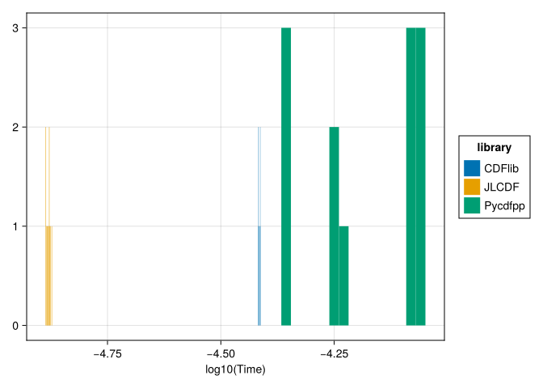

```julia
draw(data(result_open) * base_plt)
```

## Variable listing

List variables names without requesting values.

```julia
jl_res = JLCDF.list_variables(files[1])
cdfpp_res = pyconvert(Vector{String}, Pycdfpp.list_variables(files[1]))
cdflib_res = pyconvert(Vector{String}, CDFlib.list_variables(files[1]))
@assert jl_res == cdfpp_res
@assert jl_res == cdflib_res

result_list = run_benchmarks(files, libs, :list_variables; evals=4) |> DataFrame
```

36×5 DataFrame

11 rows omitted

| Row | file String | library Symbol | task Symbol | time Float64 | evals Float64 |
| --- | --- | --- | --- | --- | --- |
| 1 | mms1_scm_srvy_l2_scsrvy_20190301_v2.2.0.cdf | JLCDF | list_variables | 1.56148e-5 | 4.0 |
| 2 | mms1_edp_fast_l2_dce_20221110_v3.1.0.cdf | JLCDF | list_variables | 3.0573e-5 | 4.0 |
| 3 | mms1_fpi_fast_l2_des-dist_20221103060000_v3.4.0.cdf | JLCDF | list_variables | 1.55728e-5 | 4.0 |
| 4 | solo_l3_rpw-bia-efield_20220220_v03.cdf | JLCDF | list_variables | 1.43648e-5 | 4.0 |
| 5 | mms1_scm_srvy_l2_scsrvy_20190301_v2.2.0.cdf | Pycdfpp | list_variables | 0.000391188 | 4.0 |
| 6 | mms1_edp_fast_l2_dce_20221110_v3.1.0.cdf | Pycdfpp | list_variables | 0.000435938 | 4.0 |
| 7 | mms1_fpi_fast_l2_des-dist_20221103060000_v3.4.0.cdf | Pycdfpp | list_variables | 0.00044026 | 4.0 |
| 8 | solo_l3_rpw-bia-efield_20220220_v03.cdf | Pycdfpp | list_variables | 0.000403771 | 4.0 |
| 9 | mms1_scm_srvy_l2_scsrvy_20190301_v2.2.0.cdf | CDFlib | list_variables | 0.000292573 | 4.0 |
| 10 | mms1_edp_fast_l2_dce_20221110_v3.1.0.cdf | CDFlib | list_variables | 0.000311042 | 4.0 |
| 11 | mms1_fpi_fast_l2_des-dist_20221103060000_v3.4.0.cdf | CDFlib | list_variables | 0.00040625 | 4.0 |
| 12 | solo_l3_rpw-bia-efield_20220220_v03.cdf | CDFlib | list_variables | 0.000444688 | 4.0 |
| 13 | mms1_scm_srvy_l2_scsrvy_20190301_v2.2.0.cdf | JLCDF | list_variables | 1.56668e-5 | 4.0 |
| ⋮ | ⋮ | ⋮ | ⋮ | ⋮ | ⋮ |
| 25 | mms1_scm_srvy_l2_scsrvy_20190301_v2.2.0.cdf | JLCDF | list_variables | 1.56665e-5 | 4.0 |
| 26 | mms1_edp_fast_l2_dce_20221110_v3.1.0.cdf | JLCDF | list_variables | 3.0552e-5 | 4.0 |
| 27 | mms1_fpi_fast_l2_des-dist_20221103060000_v3.4.0.cdf | JLCDF | list_variables | 1.53645e-5 | 4.0 |
| 28 | solo_l3_rpw-bia-efield_20220220_v03.cdf | JLCDF | list_variables | 1.42813e-5 | 4.0 |
| 29 | mms1_scm_srvy_l2_scsrvy_20190301_v2.2.0.cdf | Pycdfpp | list_variables | 0.000394115 | 4.0 |
| 30 | mms1_edp_fast_l2_dce_20221110_v3.1.0.cdf | Pycdfpp | list_variables | 0.000440375 | 4.0 |
| 31 | mms1_fpi_fast_l2_des-dist_20221103060000_v3.4.0.cdf | Pycdfpp | list_variables | 0.000439417 | 4.0 |
| 32 | solo_l3_rpw-bia-efield_20220220_v03.cdf | Pycdfpp | list_variables | 0.000407417 | 4.0 |
| 33 | mms1_scm_srvy_l2_scsrvy_20190301_v2.2.0.cdf | CDFlib | list_variables | 0.000290969 | 4.0 |
| 34 | mms1_edp_fast_l2_dce_20221110_v3.1.0.cdf | CDFlib | list_variables | 0.000313563 | 4.0 |
| 35 | mms1_fpi_fast_l2_des-dist_20221103060000_v3.4.0.cdf | CDFlib | list_variables | 0.000398938 | 4.0 |
| 36 | solo_l3_rpw-bia-efield_20220220_v03.cdf | CDFlib | list_variables | 0.000452719 | 4.0 |

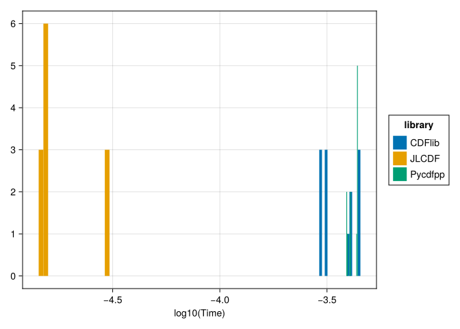

```julia
draw(data(result_list) * base_plt)
```

## Variable reading

We request the first variable values. Julia is column major, while CDFpp and CDFlib are row major (C++ and Python).

```julia
jl_res = permutedims(JLCDF.get_var_data(files[1]), (2, 1))
cdfpp_res = PyArray(Pycdfpp.get_var_data(files[1]))
cdflib_res = PyArray(CDFlib.get_var_data(files[1]))
@assert jl_res[.!isnan.(jl_res)] ≈ cdfpp_res[.!isnan.(cdfpp_res)]
@assert jl_res[.!isnan.(jl_res)] ≈ cdflib_res[.!isnan.(cdflib_res)]

result_read = run_benchmarks(files, libs, :get_var_data; evals=2, n=4) |> DataFrame
```

48×5 DataFrame

23 rows omitted

| Row | file String | library Symbol | task Symbol | time Float64 | evals Float64 |
| --- | --- | --- | --- | --- | --- |
| 1 | mms1_scm_srvy_l2_scsrvy_20190301_v2.2.0.cdf | JLCDF | get_var_data | 0.00955642 | 2.0 |
| 2 | mms1_edp_fast_l2_dce_20221110_v3.1.0.cdf | JLCDF | get_var_data | 0.00239421 | 2.0 |
| 3 | mms1_fpi_fast_l2_des-dist_20221103060000_v3.4.0.cdf | JLCDF | get_var_data | 1.85625e-5 | 2.0 |
| 4 | solo_l3_rpw-bia-efield_20220220_v03.cdf | JLCDF | get_var_data | 0.0113477 | 2.0 |
| 5 | mms1_scm_srvy_l2_scsrvy_20190301_v2.2.0.cdf | Pycdfpp | get_var_data | 0.0717563 | 2.0 |
| 6 | mms1_edp_fast_l2_dce_20221110_v3.1.0.cdf | Pycdfpp | get_var_data | 0.00296454 | 2.0 |
| 7 | mms1_fpi_fast_l2_des-dist_20221103060000_v3.4.0.cdf | Pycdfpp | get_var_data | 0.000437375 | 2.0 |
| 8 | solo_l3_rpw-bia-efield_20220220_v03.cdf | Pycdfpp | get_var_data | 0.0118374 | 2.0 |
| 9 | mms1_scm_srvy_l2_scsrvy_20190301_v2.2.0.cdf | CDFlib | get_var_data | 0.137004 | 2.0 |
| 10 | mms1_edp_fast_l2_dce_20221110_v3.1.0.cdf | CDFlib | get_var_data | 0.00778117 | 2.0 |
| 11 | mms1_fpi_fast_l2_des-dist_20221103060000_v3.4.0.cdf | CDFlib | get_var_data | 0.000434875 | 2.0 |
| 12 | solo_l3_rpw-bia-efield_20220220_v03.cdf | CDFlib | get_var_data | 0.0296159 | 2.0 |
| 13 | mms1_scm_srvy_l2_scsrvy_20190301_v2.2.0.cdf | JLCDF | get_var_data | 0.00943675 | 2.0 |
| ⋮ | ⋮ | ⋮ | ⋮ | ⋮ | ⋮ |
| 37 | mms1_scm_srvy_l2_scsrvy_20190301_v2.2.0.cdf | JLCDF | get_var_data | 0.00938646 | 2.0 |
| 38 | mms1_edp_fast_l2_dce_20221110_v3.1.0.cdf | JLCDF | get_var_data | 0.00238021 | 2.0 |
| 39 | mms1_fpi_fast_l2_des-dist_20221103060000_v3.4.0.cdf | JLCDF | get_var_data | 1.8208e-5 | 2.0 |
| 40 | solo_l3_rpw-bia-efield_20220220_v03.cdf | JLCDF | get_var_data | 0.0111861 | 2.0 |
| 41 | mms1_scm_srvy_l2_scsrvy_20190301_v2.2.0.cdf | Pycdfpp | get_var_data | 0.0715051 | 2.0 |
| 42 | mms1_edp_fast_l2_dce_20221110_v3.1.0.cdf | Pycdfpp | get_var_data | 0.00295673 | 2.0 |
| 43 | mms1_fpi_fast_l2_des-dist_20221103060000_v3.4.0.cdf | Pycdfpp | get_var_data | 0.000433917 | 2.0 |
| 44 | solo_l3_rpw-bia-efield_20220220_v03.cdf | Pycdfpp | get_var_data | 0.0115245 | 2.0 |
| 45 | mms1_scm_srvy_l2_scsrvy_20190301_v2.2.0.cdf | CDFlib | get_var_data | 0.138544 | 2.0 |
| 46 | mms1_edp_fast_l2_dce_20221110_v3.1.0.cdf | CDFlib | get_var_data | 0.00765619 | 2.0 |
| 47 | mms1_fpi_fast_l2_des-dist_20221103060000_v3.4.0.cdf | CDFlib | get_var_data | 0.000432104 | 2.0 |
| 48 | solo_l3_rpw-bia-efield_20220220_v03.cdf | CDFlib | get_var_data | 0.0302381 | 2.0 |

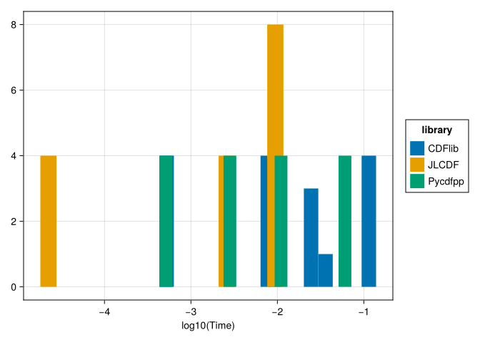

```julia
draw(data(result_read) * base_plt)
```

## Full CDF file loading

We request all variables values.

```julia
result_full = run_benchmarks(files, libs, :full_load; evals=2, n=2) |> DataFrame
```

24×5 DataFrame

| Row | file String | library Symbol | task Symbol | time Float64 | evals Float64 |
| --- | --- | --- | --- | --- | --- |
| 1 | mms1_scm_srvy_l2_scsrvy_20190301_v2.2.0.cdf | JLCDF | full_load | 0.0125854 | 2.0 |
| 2 | mms1_edp_fast_l2_dce_20221110_v3.1.0.cdf | JLCDF | full_load | 0.121065 | 2.0 |
| 3 | mms1_fpi_fast_l2_des-dist_20221103060000_v3.4.0.cdf | JLCDF | full_load | 0.0643002 | 2.0 |
| 4 | solo_l3_rpw-bia-efield_20220220_v03.cdf | JLCDF | full_load | 0.0866738 | 2.0 |
| 5 | mms1_scm_srvy_l2_scsrvy_20190301_v2.2.0.cdf | Pycdfpp | full_load | 0.0807833 | 2.0 |
| 6 | mms1_edp_fast_l2_dce_20221110_v3.1.0.cdf | Pycdfpp | full_load | 0.622828 | 2.0 |
| 7 | mms1_fpi_fast_l2_des-dist_20221103060000_v3.4.0.cdf | Pycdfpp | full_load | 0.448834 | 2.0 |
| 8 | solo_l3_rpw-bia-efield_20220220_v03.cdf | Pycdfpp | full_load | 0.326105 | 2.0 |
| 9 | mms1_scm_srvy_l2_scsrvy_20190301_v2.2.0.cdf | CDFlib | full_load | 0.984941 | 2.0 |
| 10 | mms1_edp_fast_l2_dce_20221110_v3.1.0.cdf | CDFlib | full_load | 1.22249 | 2.0 |
| 11 | mms1_fpi_fast_l2_des-dist_20221103060000_v3.4.0.cdf | CDFlib | full_load | 0.795301 | 2.0 |
| 12 | solo_l3_rpw-bia-efield_20220220_v03.cdf | CDFlib | full_load | 0.703445 | 2.0 |
| 13 | mms1_scm_srvy_l2_scsrvy_20190301_v2.2.0.cdf | JLCDF | full_load | 0.0126343 | 2.0 |
| 14 | mms1_edp_fast_l2_dce_20221110_v3.1.0.cdf | JLCDF | full_load | 0.12459 | 2.0 |
| 15 | mms1_fpi_fast_l2_des-dist_20221103060000_v3.4.0.cdf | JLCDF | full_load | 0.0614843 | 2.0 |
| 16 | solo_l3_rpw-bia-efield_20220220_v03.cdf | JLCDF | full_load | 0.0767648 | 2.0 |
| 17 | mms1_scm_srvy_l2_scsrvy_20190301_v2.2.0.cdf | Pycdfpp | full_load | 0.0800061 | 2.0 |
| 18 | mms1_edp_fast_l2_dce_20221110_v3.1.0.cdf | Pycdfpp | full_load | 0.62036 | 2.0 |
| 19 | mms1_fpi_fast_l2_des-dist_20221103060000_v3.4.0.cdf | Pycdfpp | full_load | 0.443924 | 2.0 |
| 20 | solo_l3_rpw-bia-efield_20220220_v03.cdf | Pycdfpp | full_load | 0.327757 | 2.0 |
| 21 | mms1_scm_srvy_l2_scsrvy_20190301_v2.2.0.cdf | CDFlib | full_load | 0.958206 | 2.0 |
| 22 | mms1_edp_fast_l2_dce_20221110_v3.1.0.cdf | CDFlib | full_load | 1.25364 | 2.0 |
| 23 | mms1_fpi_fast_l2_des-dist_20221103060000_v3.4.0.cdf | CDFlib | full_load | 0.823466 | 2.0 |
| 24 | solo_l3_rpw-bia-efield_20220220_v03.cdf | CDFlib | full_load | 0.717578 | 2.0 |

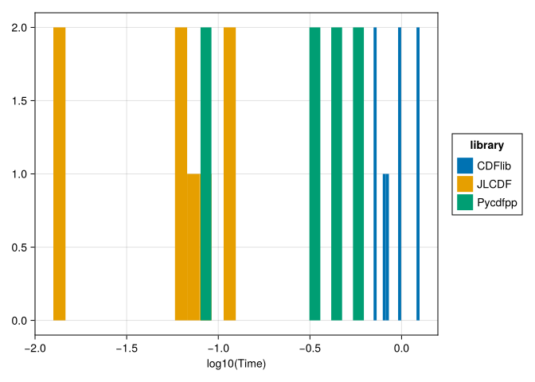

```julia
draw(data(result_full) * base_plt)
```

## Summary

```julia
result = vcat(result_open, result_list, result_read, result_full)
```

144×5 DataFrame

119 rows omitted

| Row | file String | library Symbol | task Symbol | time Float64 | evals Float64 |
| --- | --- | --- | --- | --- | --- |
| 1 | mms1_scm_srvy_l2_scsrvy_20190301_v2.2.0.cdf | JLCDF | load | 1.30523e-5 | 4.0 |
| 2 | mms1_edp_fast_l2_dce_20221110_v3.1.0.cdf | JLCDF | load | 1.30105e-5 | 4.0 |
| 3 | mms1_fpi_fast_l2_des-dist_20221103060000_v3.4.0.cdf | JLCDF | load | 1.32605e-5 | 4.0 |
| 4 | solo_l3_rpw-bia-efield_20220220_v03.cdf | JLCDF | load | 1.31665e-5 | 4.0 |
| 5 | mms1_scm_srvy_l2_scsrvy_20190301_v2.2.0.cdf | Pycdfpp | load | 4.38438e-5 | 4.0 |
| 6 | mms1_edp_fast_l2_dce_20221110_v3.1.0.cdf | Pycdfpp | load | 8.9375e-5 | 4.0 |
| 7 | mms1_fpi_fast_l2_des-dist_20221103060000_v3.4.0.cdf | Pycdfpp | load | 8.23645e-5 | 4.0 |
| 8 | solo_l3_rpw-bia-efield_20220220_v03.cdf | Pycdfpp | load | 5.77603e-5 | 4.0 |
| 9 | mms1_scm_srvy_l2_scsrvy_20190301_v2.2.0.cdf | CDFlib | load | 3.87605e-5 | 4.0 |
| 10 | mms1_edp_fast_l2_dce_20221110_v3.1.0.cdf | CDFlib | load | 3.83125e-5 | 4.0 |
| 11 | mms1_fpi_fast_l2_des-dist_20221103060000_v3.4.0.cdf | CDFlib | load | 3.84792e-5 | 4.0 |
| 12 | solo_l3_rpw-bia-efield_20220220_v03.cdf | CDFlib | load | 3.8677e-5 | 4.0 |
| 13 | mms1_scm_srvy_l2_scsrvy_20190301_v2.2.0.cdf | JLCDF | load | 1.34165e-5 | 4.0 |
| ⋮ | ⋮ | ⋮ | ⋮ | ⋮ | ⋮ |
| 133 | mms1_scm_srvy_l2_scsrvy_20190301_v2.2.0.cdf | JLCDF | full_load | 0.0126343 | 2.0 |
| 134 | mms1_edp_fast_l2_dce_20221110_v3.1.0.cdf | JLCDF | full_load | 0.12459 | 2.0 |
| 135 | mms1_fpi_fast_l2_des-dist_20221103060000_v3.4.0.cdf | JLCDF | full_load | 0.0614843 | 2.0 |
| 136 | solo_l3_rpw-bia-efield_20220220_v03.cdf | JLCDF | full_load | 0.0767648 | 2.0 |
| 137 | mms1_scm_srvy_l2_scsrvy_20190301_v2.2.0.cdf | Pycdfpp | full_load | 0.0800061 | 2.0 |
| 138 | mms1_edp_fast_l2_dce_20221110_v3.1.0.cdf | Pycdfpp | full_load | 0.62036 | 2.0 |
| 139 | mms1_fpi_fast_l2_des-dist_20221103060000_v3.4.0.cdf | Pycdfpp | full_load | 0.443924 | 2.0 |
| 140 | solo_l3_rpw-bia-efield_20220220_v03.cdf | Pycdfpp | full_load | 0.327757 | 2.0 |
| 141 | mms1_scm_srvy_l2_scsrvy_20190301_v2.2.0.cdf | CDFlib | full_load | 0.958206 | 2.0 |
| 142 | mms1_edp_fast_l2_dce_20221110_v3.1.0.cdf | CDFlib | full_load | 1.25364 | 2.0 |
| 143 | mms1_fpi_fast_l2_des-dist_20221103060000_v3.4.0.cdf | CDFlib | full_load | 0.823466 | 2.0 |
| 144 | solo_l3_rpw-bia-efield_20220220_v03.cdf | CDFlib | full_load | 0.717578 | 2.0 |

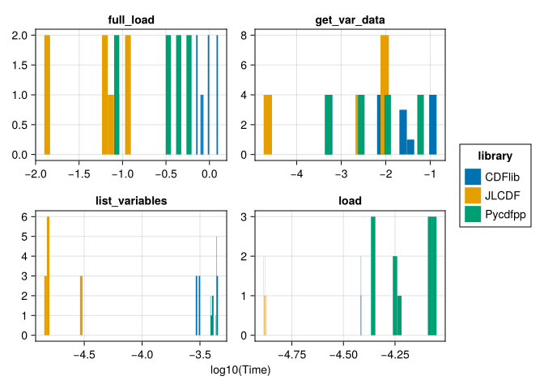

```julia
plt = data(result) * mapping(layout=:task) * base_plt
draw(plt; facet=(; linkxaxes=:none, linkyaxes=:none))
```

## Reproducibility

**NoteThis tutorial was built using these direct dependencies**

```julia
using Pkg
Pkg.status()
```

```
Status `~/src/juliaspacephysics.github.io/tutorials/cdf/Project.toml`
  [cbdf2221] AlgebraOfGraphics v0.11.8
  [13f3f980] CairoMakie v0.15.6
  [0ca39b1e] Chairmarks v1.3.1
  [a9737db6] CommonDataFormat v0.1.6 `~/.julia/dev/CommonDataFormat`
  [a93c6f00] DataFrames v1.8.1
  [6099a3de] PythonCall v0.9.28
```

**NoteMachine and Julia version information**

```julia
using InteractiveUtils # hide
versioninfo()
```

```
Julia Version 1.12.1
Commit ba1e628ee49 (2025-10-17 13:02 UTC)
Build Info:
  Official https://julialang.org release
Platform Info:
  OS: macOS (arm64-apple-darwin24.0.0)
  CPU: 12 × Apple M2 Max
  WORD_SIZE: 64
  LLVM: libLLVM-18.1.7 (ORCJIT, apple-m2)
  GC: Built with stock GC
Threads: 8 default, 1 interactive, 8 GC (on 8 virtual cores)
Environment:
  JULIA_PROJECT = @.
  JULIA_LOAD_PATH = @:@stdlib
```

Back to top